# Vermont

In Prison Past Their  
Parole Eligibility*

Prison Population Incarcerated Past Their Parole Eligibility*

Parole Board  
Members

*Only includes people in prison for new offenses and sentence lengths between 1 to 25 years.

**Parole Eligibility**

## How Parole Eligibility is Determined

Parole eligibility refers to the point in a person’s prison sentence when they become eligible for consideration for release under parole. Parole is a conditional release, allowing the person to serve the remainder of their sentence in the community under supervision, rather than in prison.

Vermont judges have discretion to vary the relationship between the minimum and maximum prison terms they impose. In most cases both the judicial minimum and maximum are subject to potential reductions through credit earnings. Starting in 2021 earned time credits of 7 days per month reduce both minimum and maximum. Serious “listed” offenses are subject to traditional discretionary parole while unlisted offenses are subject to presumptive more automatic release.

## In Prison Past Their Parole Eligibility

### Demographics

**Race and Ethnicity**

**Gender**

**Age**

## State Notes

**Prison Population**

## Prison Population Trends

From 2010 to 2022, the prison population decreased 38 percent, changing from 2,079 in 2010 to 1,287 in 2022.

[interactive chart not shown]

## Demographics

**Race and Ethnicity**

In 2022, most people in prison were White, non-Hispanic people, representing 84 percent of people in prison.

[interactive chart not shown]

**Gender**

In 2022, most people in prison were males, representing 92 percent of people in prison.

[interactive chart not shown]

**Age**

In 2020, most people in prison were between 25 to 34 years old, representing 31 percent of people.

[interactive chart not shown]

## Offense Types

In 2020, most people in prison were incarcerated for rape or sexual assault, representing 25 percent of people.

[interactive chart not shown]

## Sentence Lengths

In 2020, most people in prison had sentence lengths between 10 to 24.9 years, representing 35 percent of people.

[interactive chart not shown]

**Prison Releases**

## Prison Release Trends

From 2017 to 2020, prison releases decreased 48 percent, dropping from 3,913 in 2017 to 2,018 in 2020.

[interactive chart not shown]

In 2020, 13 percent of people eligible for parole were released during their eligibility year. This represents a 13 percent increase compared to 2010.

[interactive chart not shown]

## Conditional Releases

Conditional release involves an individual’s release under specific conditions and supervision, whereas unconditional release means the individual is released without further obligations or restrictions.

[interactive chart not shown]

## Demographics

**Race and Ethnicity**

In 2020, most people released from prison were White, non-Hispanic people, representing 90 percent of prison releases.

[interactive chart not shown]

**Gender**

In 2020, most people released from prison were males, representing 89 percent of prison releases.

[interactive chart not shown]

**Age**

In 2020, most releases from prison were people between 25 to 34 years old, representing 39 percent of prison releases.

[interactive chart not shown]

## Offense Types

In 2020, most people released from prison were incarcerated for public order offenses, representing 26 percent of people.

[interactive chart not shown]

**Disparities**

## Disparities in Incarceration

**Race and Ethnicity**

Racial and ethnic disparities in prison incarceration represents the accumulation of disparities across the system.

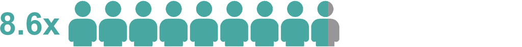

Black people are incarcerated in state prison at a rate 8.6 times higher than White people, when accounting for population sizes in Vermont.

**Gender**

Gender disparities in prison incarceration represents the accumulation of disparities across the system.

## Time Served

**Race and Ethnicity**

[interactive chart not shown]

This chart shows the average time served in prison for the most serious sentenced offense by race and ethnicity. The largest disparity was observed among rape or sexual assault offenses, where Black people spent 1.7 more years in prison on average compared to Hispanic people, who had the shortest time served for these offenses.

[interactive chart not shown]

**Gender**

This chart shows the average time served in prison for the most serious sentenced offense by gender. On average, females spent 0.1 fewer years in prison compared to males in Vermont.

[interactive chart not shown]

For other violent offenses offenses, males spent 0.8 more years in prison on average compared to females.

[interactive chart not shown]

## Disparities in Parole Eligibility

**Race and Ethnicity**

**Gender**

## Years in Prison After Parole Eligibility

**Race and Ethnicity**

**Gender**

## How Disparities Are Calculated

While White, Black, and Hispanic are not the only race and ethnicity categories found in the U.S., NCRP only provides four categories: White, Black, Hispanic, and Other. Further categories will be added in future data collections by the CSG Justice Center. Additionally, the term Hispanic is used here to maintain consistency with the data source material.

State data broken down by race and ethnicity were pulled from National Corrections Reporting Program, 1991-2020: Selected Variables (NCRP). Then, the rate of people readmitted to parole was calculated within each racial and ethnic group based on the Census Public Use Microdata Sample (PUMS). The relative rate index is calculated by dividing the rate for Black individuals or Hispanic individuals by the rate for White individuals.

*States vary in how they collect and report information about race and ethnicity. Some states use the race or ethnicity recorded by intake officers, while other states allow individuals to identify their own race and ethnicity. Furthermore, some states combine race and ethnicity into one category, while others separate them into two distinct items. These differences can result in an incomplete count of Hispanic individuals and those of mixed race in state reports. The US Census allows individuals to self-identify their race and ethnicity separately. The variation in practices across states and between state and Federal data reporting systems may result in a deflated RRI for Hispanic individuals. These differences can result in an incomplete count of Hispanic individuals and those of mixed race in state reports. Conversely, it can result in an overcount of people of other races, especially non-Hispanic White people.*

## End Notes

Data analysis was conducted using information from the National Corrections Reporting Program and the National Prisoner Statistics Program. See “National Corrections Reporting Program (NCRP),” Bureau of Justice Statistics, accessed September 25, 2024, https://bjs.ojp.gov/data-collection/national-corrections-reporting-program-ncrp; “National Prisoner Statistics (NPS) Program,” Bureau of Justice Statistics, accessed September 25, 2024, https://bjs.ojp.gov/data-collection/national-prisoner-statistics-nps-program.